# Wine

Rotem Zaarour & Dor Heldshtein & Lior Rosen

January 2018

##### The following Code requires installation packages

```r
library('dplyr')
library('ggplot2')
library('ggjoy')
library('gridExtra')
library('ggridges')
library('ngram')
library('tm')
library('SnowballC')
library('wordcloud')
library('RColorBrewer')
library('proxy')
library('RTextTools')
library('fpc')
library('cluster')
library('stringi')
```

### 1. Reading The data, EDA and data preparation

**Reading, and understanding the DATA:**

> Data source: https://www.kaggle.com/zynicide/wine-reviews/data

```r
df <- read.csv('C:/Users/My-PC/Desktop/studies/Sem02/Data_Analytics_for_Business2-G.Shama/Wine_Protject/Data/winemag-data-130k-v2.csv') # Change this path to your downloaded file
```

Exemaining n/a:

```r
# checking for missing data and cleaning the n/a
print(colSums(df == ""))
```

```
                    X               country           description           designation                points
                    0                    63                     0                 37465                     0
                price              province              region_1              region_2           taster_name
                   NA                    63                 21247                 79460                 26244
taster_twitter_handle                 title               variety                winery
                31213                     0                     1                     0
```

```r
# as we see we have some n/a in the price so we sould clean it:
df <- df[!is.na(df$price), ]
#we would also like to clean the blanks country rows:
df <- df[(df$country!= ""), ]
```

Quick glance at the data:

```r
str(df)
```

```
'data.frame':   120916 obs. of  14 variables:
 $ X                    : int  1 2 3 4 5 6 7 8 9 10 ...
 $ country              : Factor w/ 44 levels "","Argentina",..: 33 44 44 44 39 24 17 19 17 44 ...
 $ description          : Factor w/ 119955 levels "\"Chremisa,\" the ancient name of Krems, is commemorated in this wine that comes from Krems vineyards. It has t"| __truncated__,..: 99131 75516 60556 55752 22180 43058 89270 67633 91169 71422 ...
 $ designation          : Factor w/ 37980 levels "","'61 RosÃ©",..: 2404 1 28205 36717 2049 3107 1 30993 20073 23124 ...
 $ points               : int  87 87 87 87 87 87 87 87 87 87 ...
 $ price                : num  15 14 13 65 15 16 24 12 27 19 ...
 $ province             : Factor w/ 426 levels "","Ãsterreichischer Perlwein",..: 115 274 225 274 268 340 17 314 17 57 ...
 $ region_1             : Factor w/ 1230 levels "","Abruzzo","Adelaida District",..: 1 1219 552 1219 759 1206 23 1 23 755 ...
 $ region_2             : Factor w/ 18 levels "","California Other",..: 1 18 1 18 1 1 1 1 1 8 ...
 $ taster_name          : Factor w/ 20 levels "","Alexander Peartree",..: 17 16 2 16 14 11 17 3 17 20 ...
 $ taster_twitter_handle: Factor w/ 16 levels "","@AnneInVino",..: 12 9 1 9 14 6 12 1 12 11 ...
 $ title                : Factor w/ 118840 levels ":Nota Bene 2005 Una Notte Red (Washington)",..: 89460 89984 101062 102995 103761 105815 108734 54697 59245 62596 ...
 $ variety              : Factor w/ 708 levels "","ÃalkarasÄ±",..: 454 441 483 445 593 191 213 213 441 88 ...
 $ winery               : Factor w/ 16757 levels ":Nota Bene","1+1=3",..: 12989 13063 14433 14665 14742 15048 15436 8443 9000 9342 ...
```

```r
a.df = c("country","province", "region_1", "region_2", "points", "price", "designation", "variety", "winery", "taster_name")
summary(df[,a.df])
```

```
     country                province                     region_1                  region_2         points
 US      :54265   California    :36104                       :19516                    :70624   Min.   : 80.00
 France  :17776   Washington    : 8583   Napa Valley         : 4475   Central Coast    :10975   1st Qu.: 86.00
 Italy   :16914   Oregon        : 5359   Columbia Valley (WA): 4109   Sonoma           : 9009   Median : 88.00
 Spain   : 6573   Tuscany       : 5128   Russian River Valley: 3090   Columbia Valley  : 8058   Mean   : 88.42
 Portugal: 4875   Bordeaux      : 4002   California          : 2627   Napa             : 6804   3rd Qu.: 91.00
 Chile   : 4416   Northern Spain: 3797   Paso Robles         : 2327   Willamette Valley: 3416   Max.   :100.00
 (Other) :16097   (Other)       :57943   (Other)             :84772   (Other)          :12030
     price               designation                        variety                        winery
 Min.   :   4.00               :34768   Pinot Noir              :12785   Testarossa           :   217
 1st Qu.:  17.00   Reserve     : 1977   Chardonnay              :11077   Williams Selyem      :   211
 Median :  25.00   Estate      : 1317   Cabernet Sauvignon      : 9384   DFJ Vinhos           :   209
 Mean   :  35.37   Reserva     : 1219   Red Blend               : 8466   Wines & Winemakers   :   209
 3rd Qu.:  42.00   Estate Grown:  618   Bordeaux-style Red Blend: 5340   Chateau Ste. Michelle:   193
 Max.   :3300.00   Riserva     :  607   Riesling                : 4971   Louis Latour         :   173
                   (Other)     :80410   (Other)                 :68893   (Other)              :119704
            taster_name
                  :24496
 Roger Voss       :20172
 Michael Schachner:14944
 Kerin OâKeefe  : 9874
 Virginie Boone   : 9507
 Paul Gregutt     : 9497
 (Other)          :32426
```

Summary of unique values:

```r
unique_vals <- sapply(df, unique)
summary(unique_vals)
```

```
                      Length Class  Mode
X                     120916 -none- numeric
country                   42 factor numeric
description           111512 factor numeric
designation            35754 factor numeric
points                    21 -none- numeric
price                    390 -none- numeric
province                 422 factor numeric
region_1                1205 factor numeric
region_2                  18 factor numeric
taster_name               20 factor numeric
taster_twitter_handle     16 factor numeric
title                 110583 factor numeric
variety                  692 factor numeric
winery                 15843 factor numeric
```

**Exploring the DATA**

Defining wine types by red and white

```r
# in this chunk we will use library(dplyr)
df$wine_type = ifelse(df$variety == "Chardonnay" | df$variety == "Riesling" | df$variety == "Sauvignon Blanc" | df$variety == "White Blend" | df$variety == "Sparkling Blend" | df$variety == "Pinot Gris" | df$variety == "Champagne Blend" | df$variety == "GrÃ¼ner Veltliner" | df$variety == "Pinot Grigio" | df$variety == "Portuguese White" | df$variety == "Viognier" | df$variety == "GewÃ¼rztraminer" | df$variety == "GewÃ¼rztraminer",
                              "White Wine",
                              "Red Wine")
df$wine_type = as.factor(df$wine_type)
summary(df$wine_type)
```

```
  Red Wine White Wine
     88222      32694
```

adding the ratio between price and points:

```r
df$ratio = ((log(df$price))/df$points)*100
summary(df$ratio)
```

```
   Min. 1st Qu.  Median    Mean 3rd Qu.    Max.
  1.612   3.248   3.695   3.738   4.183   9.206
```

**Lets inspect the DATA:**

First we would like to analyze the distribution:

- the points (score) given in each wine criticism.
- the price (only under 150 to reduce the edges).
- the price’s log.

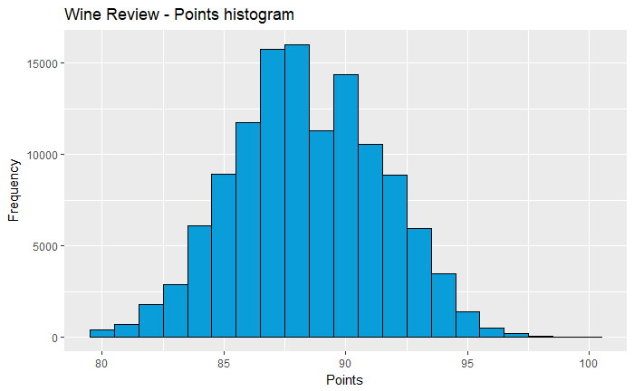

```r
# in this chunk we will use:
#library(ggplot2)
#library(ggjoy)
#library(gridExtra)
#library(ggridges)
ggplot(data = df, aes(x= points, colour = I('black'), fill = I('#099DD9')))+geom_histogram(binwidth = 1)+labs(x = "Points", y= "Frequency", title = "Wine Review - Points histogram")
```

```r
summary(df$points)
```

```
   Min. 1st Qu.  Median    Mean 3rd Qu.    Max.
  80.00   86.00   88.00   88.42   91.00  100.00
```

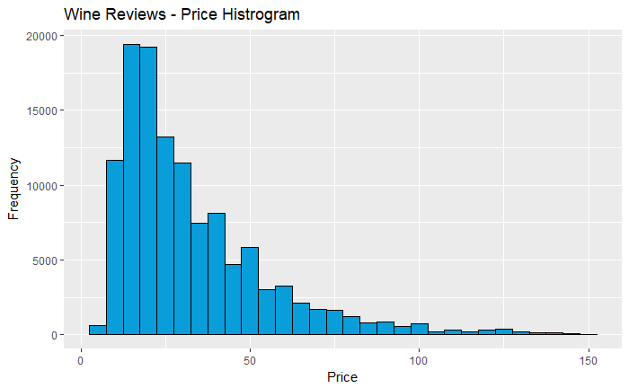

```r
ggplot(data = df[(df$price<150),], aes(x= price, colour = I('black'), fill = I('#099DD9')))+geom_histogram()+labs(x = "Price", y= "Frequency", title = "Wine Reviews - Price Histrogram")
```

```r
summary(df$price)
```

```
   Min. 1st Qu.  Median    Mean 3rd Qu.    Max.
   4.00   17.00   25.00   35.37   42.00 3300.00
```

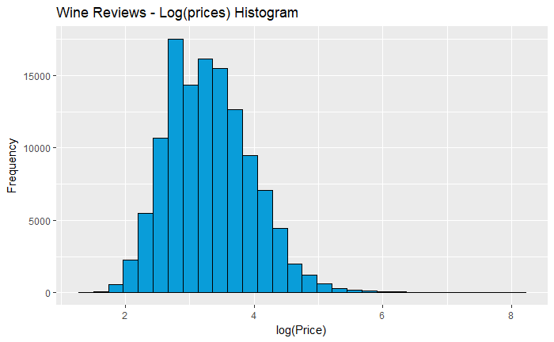

```r
ggplot(data = df, aes(x= log(price), colour = I('black'), fill = I('#099DD9')))+geom_histogram()+labs(x = "log(Price)", y= "Frequency", title = "Wine Reviews - Log(prices) Histogram")
```

```r
summary(log(df$price))
```

```
   Min. 1st Qu.  Median    Mean 3rd Qu.    Max.
  1.386   2.833   3.219   3.315   3.738   8.102
```

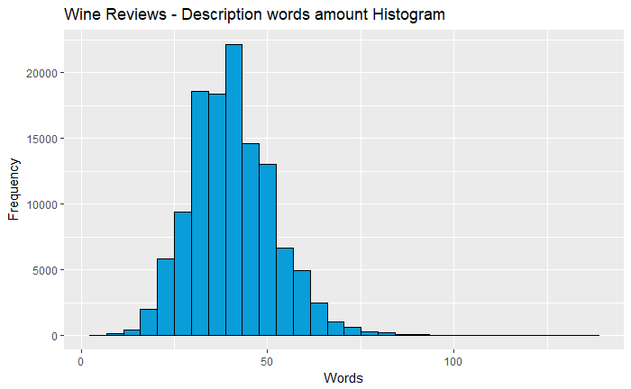

```r
desc = data.frame(nw = (lengths(gregexpr(" ", df$description))+1))
ggplot(data = desc, aes(x= nw, colour = I('black'), fill = I('#099DD9')))+geom_histogram()+labs(x = "Words", y= "Frequency", title = "Wine Reviews - Description words amount Histogram")
```

```r
summary(desc$nw)
```

```
   Min. 1st Qu.  Median    Mean 3rd Qu.    Max.
   3.00   33.00   40.00   40.63   47.00  135.00
```

Now we would like to take a closer look at the differences between white and red wines, among the top 20 wine varieties in the data:

Top 20 types of wine

```r
top_20_wines <- df %>%
  group_by(variety) %>%
  summarise(count = n())%>%
  arrange(desc(count))
top_20_wines <- top_20_wines[1:20,1:2]
top_20_wines
```

| variety | count |
| --- | --- |
| Pinot Noir | 12785 |
| Chardonnay | 11077 |
| Cabernet Sauvignon | 9384 |
| Red Blend | 8466 |
| Bordeaux-style Red Blend | 5340 |
| Riesling | 4971 |
| Sauvignon Blanc | 4780 |
| Syrah | 4086 |
| RosÃ© | 3261 |
| Merlot | 3061 |

[output cut: 10 more lines]

```r
top_20_wines <- top_20_wines$variety
top_20.df <- subset(df, variety %in% top_20_wines)
```

Now let’s explore how price and rating are distributed within white and red wines

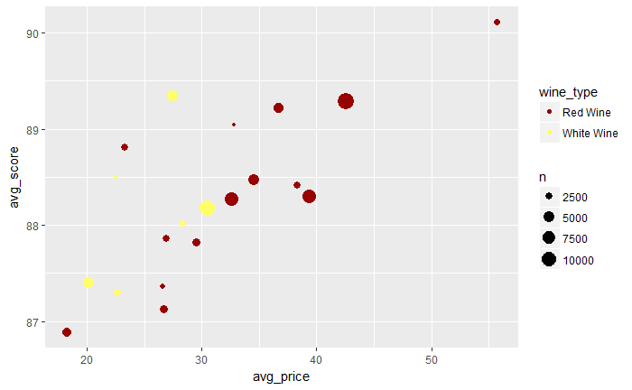

```r
top_20.df[(top_20.df$price <= 100 & top_20.df$price >0),] %>%
  group_by(variety, wine_type) %>%
  summarise(n=n(),
            avg_score = mean(points),
            avg_price = mean(price)) %>%
  ggplot(aes(x=avg_price, y= avg_score, size = n, colour = wine_type))+
  geom_point()+
  scale_color_manual(values = c("#990000", "#FFFF66"))
```

Let’s take a deeper look into specific wine varieties among the white and red groups, and see what we can learn from analyzing their price and rating (points)

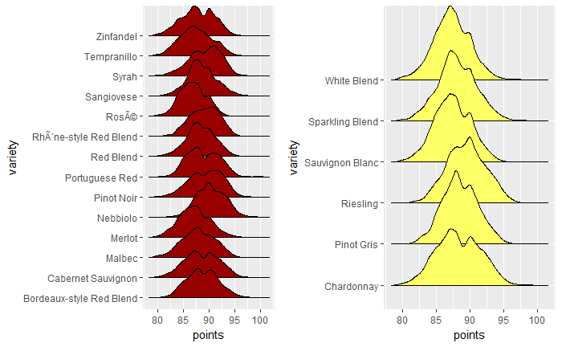

```r
p1 <- ggplot(data = subset(top_20.df, wine_type == "Red Wine"), aes(x=points, y=variety))+
  geom_density_ridges2(bandwidth = 0.539, fill = "#990000")
p2 <- ggplot(data = subset(top_20.df, wine_type == "White Wine"), aes(x=points, y=variety))+
  geom_density_ridges2(bandwidth = 0.539, fill = "#FFFF66")
grid.arrange(p1, p2, nrow = 1)
```

We will look at the log of price, in view of its broad distribution, as we saw earlier in the histogram

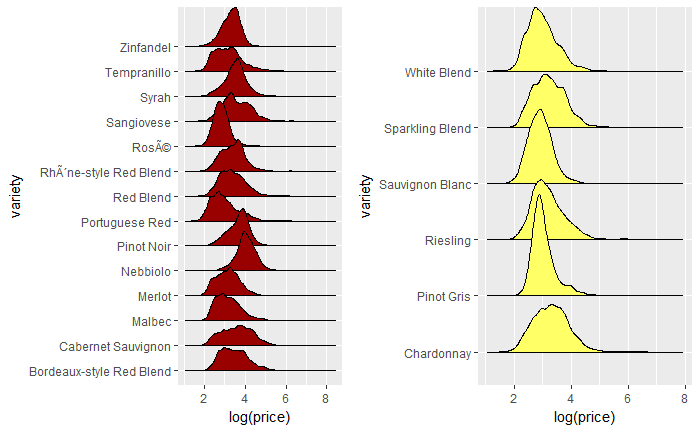

```r
p3 <- ggplot(data = subset(top_20.df, wine_type == "Red Wine"), aes(x=log(price), y=variety))+
  geom_joy2(bandwidth = 0.103, fill = "#990000")
p4 <- ggplot(data = subset(top_20.df, wine_type == "White Wine"), aes(x=log(price), y=variety))+
  geom_joy2(bandwidth = 0.103, fill = "#FFFF66")
grid.arrange(p3, p4, nrow=1)
```

Exploring the relation between price and points for white and red wines

```r
# the following requires installation of gridExtra package
p5 <- ggplot(data = subset(top_20.df, wine_type == "Red Wine"), aes(x=points, y= price))+
  geom_point(colour="#990000")+
  scale_y_log10()+
  geom_smooth()
p6 <- ggplot(data = subset(top_20.df, wine_type == "White Wine"), aes(x=points, y= price))+
  geom_point(colour="#FFFF66")+
  scale_y_log10()+
  geom_smooth()
cor(log(top_20.df$price), top_20.df$points)
```

```
[1] 0.6191505
```

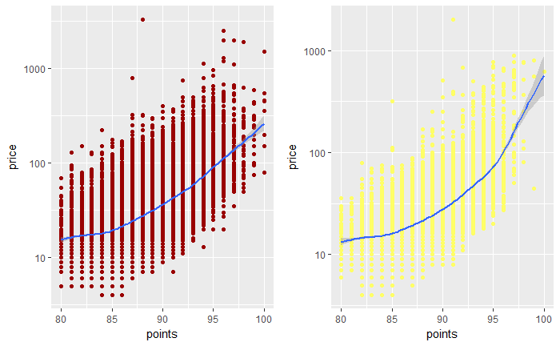

```r
grid.arrange(p5, p6, nrow=1)
```

### 2. Analyzing the data - exploring regressions

**filter and split to train and test, as learned before:**

```r
set.seed(7) # Split to train 80% and test 20%
bound <- floor((nrow(df)/5)*4)
d <- df[sample(nrow(df)), ]
df.train <- d[1:bound, ]
df.test <- d[(bound+1):nrow(df), ]
```

**prepearing the DATA:**

```r
clean_train = data.frame(points = df.train$points,
                         price = df.train$price,
                         ratio = df.train$ratio,
                         desc_nw = (lengths(gregexpr(" ", df.train$description))+1),
                         DnwPpoint = log(lengths(gregexpr(" ", df.train$description))*1)+df.train$points,
                         title_nc = nchar(as.character(df.train$title)),
                         cntry_code = as.numeric(df.train$country),
                         isred = ifelse(df.train$wine_type == "White Wine", 0, 1)
                         )
summary(clean_train)
```

```
     points           price             ratio          desc_nw         DnwPpoint         title_nc
 Min.   : 80.00   Min.   :   4.00   Min.   :1.612   Min.   :  4.00   Min.   : 81.95   Min.   : 12.00
 1st Qu.: 86.00   1st Qu.:  17.00   1st Qu.:3.248   1st Qu.: 33.00   1st Qu.: 89.74   1st Qu.: 43.00
 Median : 88.00   Median :  25.00   Median :3.695   Median : 40.00   Median : 91.78   Median : 52.00
 Mean   : 88.42   Mean   :  35.32   Mean   :3.737   Mean   : 40.64   Mean   : 92.06   Mean   : 53.19
 3rd Qu.: 91.00   3rd Qu.:  42.00   3rd Qu.:4.183   3rd Qu.: 47.00   3rd Qu.: 94.43   3rd Qu.: 62.00
 Max.   :100.00   Max.   :3300.00   Max.   :9.206   Max.   :135.00   Max.   :104.72   Max.   :136.00
   cntry_code        isred
 Min.   : 2.00   Min.   :0.00
 1st Qu.:17.00   1st Qu.:0.00
 Median :39.00   Median :1.00
 Mean   :31.25   Mean   :0.73
 3rd Qu.:44.00   3rd Qu.:1.00
 Max.   :44.00   Max.   :1.00
```

lets do the same for the test:

```r
clean_test = data.frame(points = df.test$points,
                         price = df.test$price,
                         ratio = df.test$ratio,
                         desc_nw = (lengths(gregexpr(" ", df.test$description))+1),
                         title_nc = nchar(as.character(df.test$title)),
                         cntry_code = as.numeric(df.test$country),
                         isred = ifelse(df.test$wine_type == "White Wine", 0, 1)
                         )
summary(clean_test)
```

```
     points           price             ratio          desc_nw          title_nc        cntry_code
 Min.   : 80.00   Min.   :   4.00   Min.   :1.631   Min.   :  3.00   Min.   : 16.00   Min.   : 2.00
 1st Qu.: 86.00   1st Qu.:  17.00   1st Qu.:3.248   1st Qu.: 33.00   1st Qu.: 43.00   1st Qu.:17.00
 Median : 88.00   Median :  25.00   Median :3.695   Median : 40.00   Median : 52.00   Median :39.00
 Mean   : 88.42   Mean   :  35.57   Mean   :3.739   Mean   : 40.58   Mean   : 53.12   Mean   :31.07
 3rd Qu.: 91.00   3rd Qu.:  42.00   3rd Qu.:4.183   3rd Qu.: 47.00   3rd Qu.: 62.00   3rd Qu.:44.00
 Max.   :100.00   Max.   :2500.00   Max.   :8.360   Max.   :120.00   Max.   :140.00   Max.   :44.00
     isred
 Min.   :0.0000
 1st Qu.:0.0000
 Median :1.0000
 Mean   :0.7282
 3rd Qu.:1.0000
 Max.   :1.0000
```

### Cheking for correlations:

```r
cor(clean_train[clean_train$isred == 0,], clean_train[clean_train$isred == 0,])
```

```
the standard deviation is zero
```

```
               points      price       ratio     desc_nw  DnwPpoint    title_nc  cntry_code isred
points      1.0000000  0.4407519  0.50046169  0.52953661  0.9968903  0.21813860 -0.10098836    NA
price       0.4407519  1.0000000  0.74507574  0.22805378  0.4378134  0.13900331 -0.12656303    NA
ratio       0.5004617  0.7450757  1.00000000  0.25765988  0.4975728  0.20086404 -0.09810143    NA
desc_nw     0.5295366  0.2280538  0.25765988  1.00000000  0.5920375  0.13778199 -0.08385509    NA
DnwPpoint   0.9968903  0.4378134  0.49757285  0.59203746  1.0000000  0.21931535 -0.10461513    NA
title_nc    0.2181386  0.1390033  0.20086404  0.13778199  0.2193153  1.00000000 -0.08260246    NA
cntry_code -0.1009884 -0.1265630 -0.09810143 -0.08385509 -0.1046151 -0.08260246  1.00000000    NA
isred              NA         NA          NA          NA         NA          NA          NA    NA
```

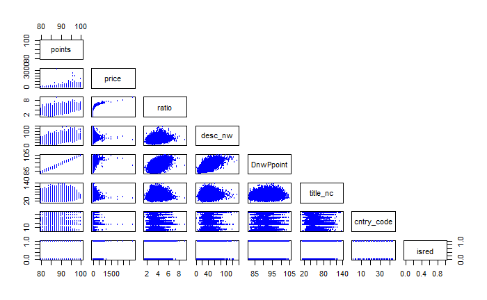

```r
pairs(clean_train, col = "blue", cex = 0.5, upper.panel = NULL)
```

Cheking the correlations of the test data:

```r
cor(clean_test, clean_test)
```

```
               points      price     ratio     desc_nw    title_nc  cntry_code       isred
points     1.00000000 0.39730605 0.4798426 0.536010175  0.14031129 0.026735972  0.02918123
price      0.39730605 1.00000000 0.6867482 0.224997552  0.04783419 0.017759678  0.07252004
ratio      0.47984262 0.68674819 1.0000000 0.279884964  0.12680533 0.128804433  0.13977279
desc_nw    0.53601018 0.22499755 0.2798850 1.000000000  0.08560093 0.003214522  0.08495499
title_nc   0.14031129 0.04783419 0.1268053 0.085600930  1.00000000 0.035787064 -0.05932022
cntry_code 0.02673597 0.01775968 0.1288044 0.003214522  0.03578706 1.000000000  0.05700906
isred      0.02918123 0.07252004 0.1397728 0.084954986 -0.05932022 0.057009059  1.00000000
```

and also the test data pairs as we did for the train data

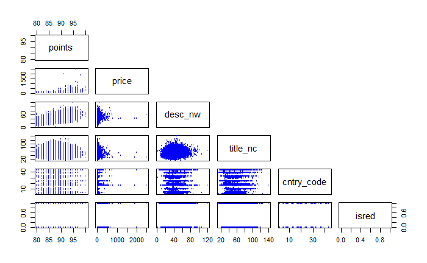

```r
pairs(clean_test[c(1-4)], col = "blue", cex = 0.5, upper.panel = NULL)
```

Now let’s explore possible regression models for predicting the price of a wine

```r
# Regression Models
# Linear Regression
Price_points_reg1 <- lm(log(price) ~ points, data = df.train)
summary(Price_points_reg1)
```

```
Call:
lm(formula = log(price) ~ points, data = df.train)

Residuals:
    Min      1Q  Median      3Q     Max
-1.7076 -0.3685 -0.0426  0.3231  4.8428

Coefficients:
              Estimate Std. Error t value Pr(>|t|)
(Intercept) -8.3151065  0.0483611  -171.9   <2e-16 ***
points       0.1315228  0.0005466   240.6   <2e-16 ***
---
Signif. codes:  0 *** 0.001 ** 0.01 * 0.05 . 0.1   1

Residual standard error: 0.5173 on 96730 degrees of freedom
Multiple R-squared:  0.3744,    Adjusted R-squared:  0.3744
F-statistic: 5.79e+04 on 1 and 96730 DF,  p-value: < 2.2e-16
```

```r
par(mfrow = c(2,2))
plot(Price_points_reg1)
Price_points_reg2 <- lm(log(price) ~ points + wine_type, data = df.train)
summary(Price_points_reg2)
```

```
Call:
lm(formula = log(price) ~ points + wine_type, data = df.train)

Residuals:
    Min      1Q  Median      3Q     Max
-1.7530 -0.3613 -0.0431  0.3216  4.7951

Coefficients:
                      Estimate Std. Error t value Pr(>|t|)
(Intercept)         -8.2010599  0.0478711 -171.31   <2e-16 ***
points               0.1307688  0.0005406  241.88   <2e-16 ***
wine_typeWhite Wine -0.1754540  0.0037055  -47.35   <2e-16 ***
---
Signif. codes:  0 *** 0.001 ** 0.01 * 0.05 . 0.1   1

Residual standard error: 0.5114 on 96729 degrees of freedom
Multiple R-squared:  0.3886,    Adjusted R-squared:  0.3886
F-statistic: 3.074e+04 on 2 and 96729 DF,  p-value: < 2.2e-16
```

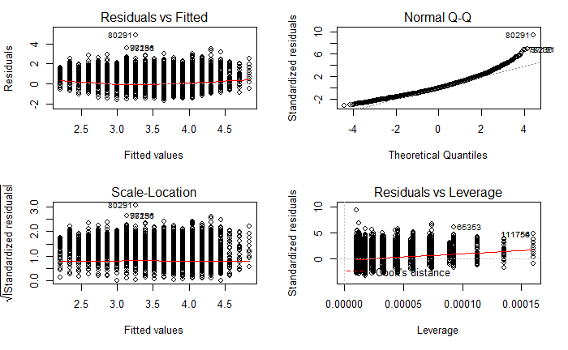

```r
par(mfrow = c(2,2))
```

```r
plot(Price_points_reg2)
Price_points_reg3 <- lm(log(price) ~ points^2 + points + wine_type, data = df.train)
summary(Price_points_reg3)
```

```
Call:
lm(formula = log(price) ~ points^2 + points + wine_type, data = df.train)

Residuals:
    Min      1Q  Median      3Q     Max
-1.7530 -0.3613 -0.0431  0.3216  4.7951

Coefficients:
                      Estimate Std. Error t value Pr(>|t|)
(Intercept)         -8.2010599  0.0478711 -171.31   <2e-16 ***
points               0.1307688  0.0005406  241.88   <2e-16 ***
wine_typeWhite Wine -0.1754540  0.0037055  -47.35   <2e-16 ***
---
Signif. codes:  0 *** 0.001 ** 0.01 * 0.05 . 0.1   1

Residual standard error: 0.5114 on 96729 degrees of freedom
Multiple R-squared:  0.3886,    Adjusted R-squared:  0.3886
F-statistic: 3.074e+04 on 2 and 96729 DF,  p-value: < 2.2e-16
```

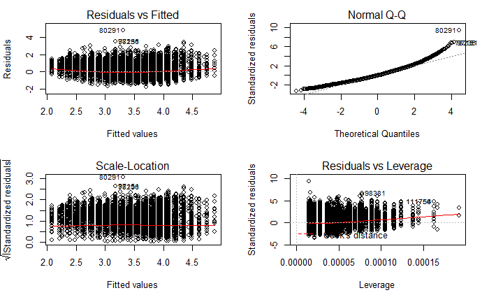

```r
par(mfrow = c(2,2))
```

```r
plot(Price_points_reg3)
Price_points_reg4 <- lm(log(price) ~ points + desc_nw, data = clean_train)
summary(Price_points_reg4)
```

```
Call:
lm(formula = log(price) ~ points + desc_nw, data = clean_train)

Residuals:
    Min      1Q  Median      3Q     Max
-1.7097 -0.3737 -0.0475  0.3217  4.8425

Coefficients:
              Estimate Std. Error  t value Pr(>|t|)
(Intercept) -8.1036444  0.0536046 -151.174   <2e-16 ***
points       0.1283918  0.0006451  199.020   <2e-16 ***
desc_nw      0.0016090  0.0001763    9.128   <2e-16 ***
---
Signif. codes:  0 *** 0.001 ** 0.01 * 0.05 . 0.1   1

Residual standard error: 0.5171 on 96729 degrees of freedom
Multiple R-squared:  0.375, Adjusted R-squared:  0.3749
F-statistic: 2.901e+04 on 2 and 96729 DF,  p-value: < 2.2e-16
```

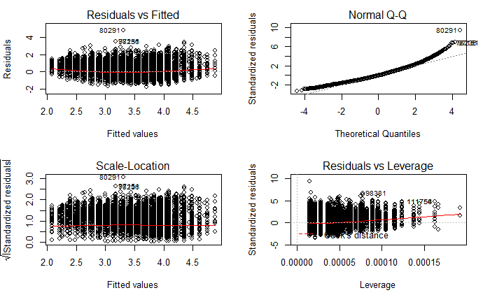

```r
par(mfrow = c(2,2))
```

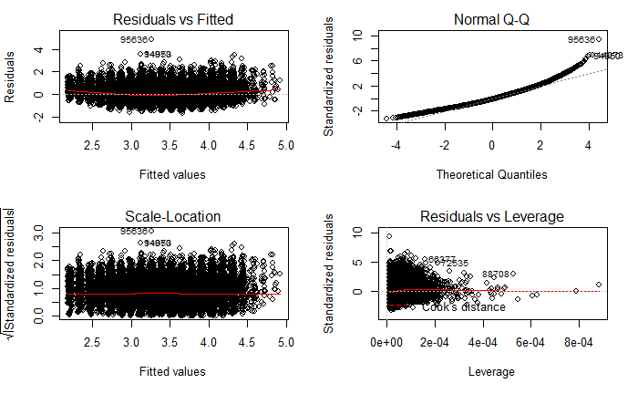

```r
plot(Price_points_reg4)
```

Now let’s explore additional regression models for predicting the ratio between wine’s rating and price

```r
# Regression Models
# Linear Regression
lior_df = clean_train
#lior_df$ratio = log(lior_df$price) / (lior_df$points + 1)
lior_df$ratio = (lior_df$points + 1) / log(lior_df$price)
Price_points_reg5 <- lm(ratio ~ desc_nw, data = lior_df)
summary(Price_points_reg5)
```

```
Call:
lm(formula = ratio ~ desc_nw, data = lior_df)

Residuals:
    Min      1Q  Median      3Q     Max
-17.010  -3.487  -0.410   3.064  33.440

Coefficients:
             Estimate Std. Error t value Pr(>|t|)
(Intercept) 32.848873   0.058252  563.90   <2e-16 ***
desc_nw     -0.121329   0.001382  -87.76   <2e-16 ***
---
Signif. codes:  0 *** 0.001 ** 0.01 * 0.05 . 0.1   1

Residual standard error: 4.789 on 96730 degrees of freedom
Multiple R-squared:  0.07376,   Adjusted R-squared:  0.07375
F-statistic:  7703 on 1 and 96730 DF,  p-value: < 2.2e-16
```

```r
par(mfrow = c(2,2))
plot(Price_points_reg5)
Price_points_reg6 <- lm(ratio ~ cntry_code + desc_nw, data = lior_df)
summary(Price_points_reg6)
```

```
Call:
lm(formula = ratio ~ cntry_code + desc_nw, data = lior_df)

Residuals:
    Min      1Q  Median      3Q     Max
-17.775  -3.325  -0.347   2.964  33.755

Coefficients:
             Estimate Std. Error t value Pr(>|t|)
(Intercept) 34.505892   0.066739  517.03   <2e-16 ***
cntry_code  -0.053684   0.001095  -49.01   <2e-16 ***
desc_nw     -0.120821   0.001366  -88.47   <2e-16 ***
---
Signif. codes:  0 *** 0.001 ** 0.01 * 0.05 . 0.1   1

Residual standard error: 4.73 on 96729 degrees of freedom
Multiple R-squared:  0.0962,    Adjusted R-squared:  0.09618
F-statistic:  5148 on 2 and 96729 DF,  p-value: < 2.2e-16
```

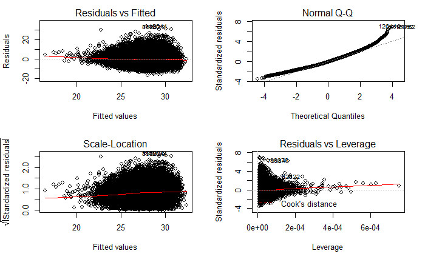

```r
par(mfrow = c(2,2))
```

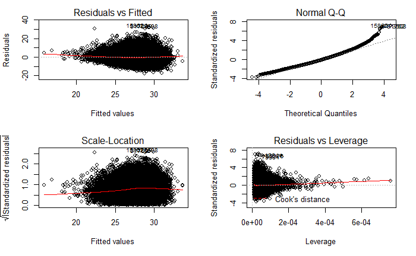

```r
plot(Price_points_reg6)
```

```r
# Applying the Regression Model on the Test Data
# Regression Models - Linear Regression
Price_points_reg1_test <- lm(log(price) ~ points, data = df.test)
summary(Price_points_reg1_test)
```

```
Call:
lm(formula = log(price) ~ points, data = df.test)

Residuals:
    Min      1Q  Median      3Q     Max
-1.4812 -0.3705 -0.0420  0.3090  3.9531

Coefficients:
            Estimate Std. Error t value Pr(>|t|)
(Intercept) -8.27912    0.09647  -85.82   <2e-16 ***
points       0.13114    0.00109  120.27   <2e-16 ***
---
Signif. codes:  0 *** 0.001 ** 0.01 * 0.05 . 0.1   1

Residual standard error: 0.5176 on 24182 degrees of freedom
Multiple R-squared:  0.3743,    Adjusted R-squared:  0.3743
F-statistic: 1.446e+04 on 1 and 24182 DF,  p-value: < 2.2e-16
```

```r
par(mfrow = c(2,2))
plot(Price_points_reg1_test)
Price_points_reg2_test <- lm(log(price) ~ points + wine_type, data = df.test)
summary(Price_points_reg2_test)
```

```
Call:
lm(formula = log(price) ~ points + wine_type, data = df.test)

Residuals:
    Min      1Q  Median      3Q     Max
-1.5288 -0.3619 -0.0465  0.3097  4.0760

Coefficients:
                     Estimate Std. Error t value Pr(>|t|)
(Intercept)         -8.171439   0.095602  -85.47   <2e-16 ***
points               0.130429   0.001080  120.81   <2e-16 ***
wine_typeWhite Wine -0.166208   0.007408  -22.44   <2e-16 ***
---
Signif. codes:  0 *** 0.001 ** 0.01 * 0.05 . 0.1   1

Residual standard error: 0.5123 on 24181 degrees of freedom
Multiple R-squared:  0.387, Adjusted R-squared:  0.387
F-statistic:  7634 on 2 and 24181 DF,  p-value: < 2.2e-16
```

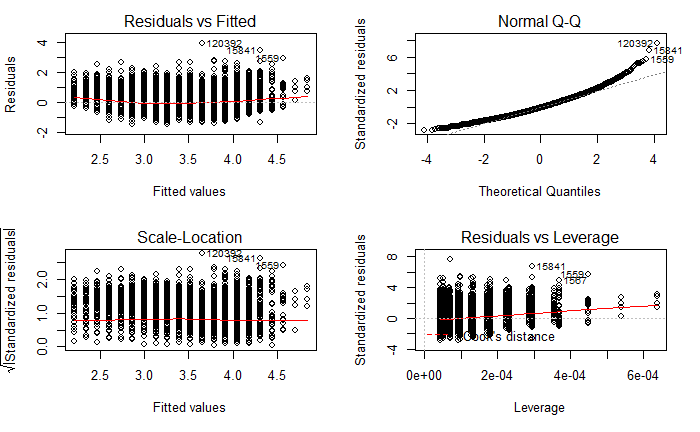

```r
par(mfrow = c(2,2))
```

```r
plot(Price_points_reg2_test)
Price_points_reg3_test <- lm(log(price) ~ points^2 + points + wine_type, data = df.test)
summary(Price_points_reg3_test)
```

```
Call:
lm(formula = log(price) ~ points^2 + points + wine_type, data = df.test)

Residuals:
    Min      1Q  Median      3Q     Max
-1.5288 -0.3619 -0.0465  0.3097  4.0760

Coefficients:
                     Estimate Std. Error t value Pr(>|t|)
(Intercept)         -8.171439   0.095602  -85.47   <2e-16 ***
points               0.130429   0.001080  120.81   <2e-16 ***
wine_typeWhite Wine -0.166208   0.007408  -22.44   <2e-16 ***
---
Signif. codes:  0 *** 0.001 ** 0.01 * 0.05 . 0.1   1

Residual standard error: 0.5123 on 24181 degrees of freedom
Multiple R-squared:  0.387, Adjusted R-squared:  0.387
F-statistic:  7634 on 2 and 24181 DF,  p-value: < 2.2e-16
```

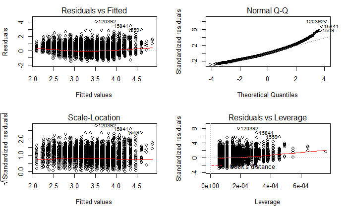

```r
par(mfrow = c(2,2))
```

```r
plot(Price_points_reg3_test)
Price_points_reg4_test <- lm(log(price) ~ points + desc_nw, data = clean_test)
summary(Price_points_reg4_test)
```

```
Call:
lm(formula = log(price) ~ points + desc_nw, data = clean_test)

Residuals:
    Min      1Q  Median      3Q     Max
-1.4848 -0.3721 -0.0462  0.3149  3.9576

Coefficients:
              Estimate Std. Error t value Pr(>|t|)
(Intercept) -8.0496299  0.1071775 -75.106  < 2e-16 ***
points       0.1277427  0.0012910  98.952  < 2e-16 ***
desc_nw      0.0017390  0.0003546   4.904 9.44e-07 ***
---
Signif. codes:  0 *** 0.001 ** 0.01 * 0.05 . 0.1   1

Residual standard error: 0.5174 on 24181 degrees of freedom
Multiple R-squared:  0.3749,    Adjusted R-squared:  0.3748
F-statistic:  7251 on 2 and 24181 DF,  p-value: < 2.2e-16
```

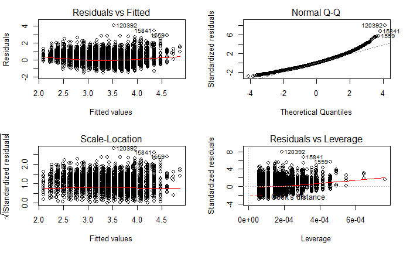

```r
par(mfrow = c(2,2))
```

```r
plot(Price_points_reg4_test)
lior_df_test = clean_test
lior_df_test$ratio = log(lior_df_test$price) / (lior_df_test$points + 1)
Price_points_reg5_test <- lm(ratio ~ desc_nw, data = lior_df_test)
summary(Price_points_reg5_test)
```

```
Call:
lm(formula = ratio ~ desc_nw, data = lior_df_test)

Residuals:
      Min        1Q    Median        3Q       Max
-0.021654 -0.004549 -0.000496  0.004073  0.045311

Coefficients:
             Estimate Std. Error t value Pr(>|t|)
(Intercept) 3.024e-02  1.536e-04  196.85   <2e-16 ***
desc_nw     1.661e-04  3.651e-06   45.49   <2e-16 ***
---
Signif. codes:  0 *** 0.001 ** 0.01 * 0.05 . 0.1   1

Residual standard error: 0.00631 on 24182 degrees of freedom
Multiple R-squared:  0.07884,   Adjusted R-squared:  0.0788
F-statistic:  2070 on 1 and 24182 DF,  p-value: < 2.2e-16
```

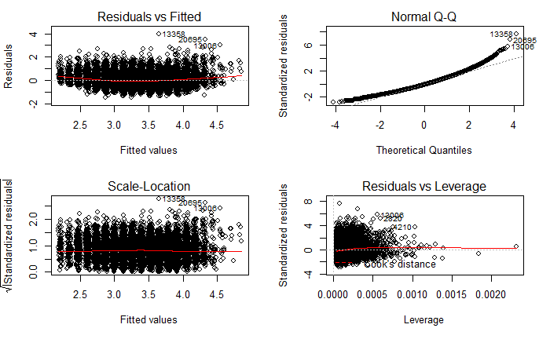

```r
par(mfrow = c(2,2))
```

```r
plot(Price_points_reg5_test)
Price_points_reg6_test <- lm(ratio ~ desc_nw^2 + desc_nw, data = lior_df_test)
summary(Price_points_reg6_test)
```

```
Call:
lm(formula = ratio ~ desc_nw^2 + desc_nw, data = lior_df_test)

Residuals:
      Min        1Q    Median        3Q       Max
-0.021654 -0.004549 -0.000496  0.004073  0.045311

Coefficients:
             Estimate Std. Error t value Pr(>|t|)
(Intercept) 3.024e-02  1.536e-04  196.85   <2e-16 ***
desc_nw     1.661e-04  3.651e-06   45.49   <2e-16 ***
---
Signif. codes:  0 *** 0.001 ** 0.01 * 0.05 . 0.1   1

Residual standard error: 0.00631 on 24182 degrees of freedom
Multiple R-squared:  0.07884,   Adjusted R-squared:  0.0788
F-statistic:  2070 on 1 and 24182 DF,  p-value: < 2.2e-16
```

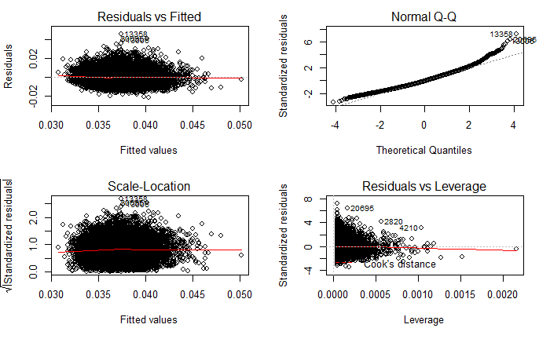

```r
par(mfrow = c(2,2))
```

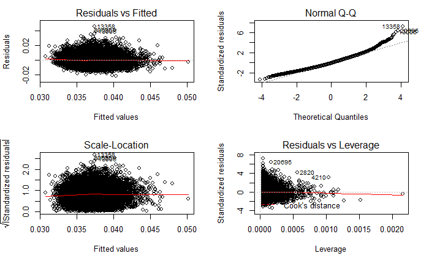

```r
plot(Price_points_reg6_test)
```

### 3. Analyzing the Wine Reviews Text

Textual Mining of the wine reviews

```r
# Textual analysis of the wine reviews
# in this chunk we will use:
#library("ggplot2")
#library("ngram")
#library("ggridges")
# Analyzing how many words are there in each review
df.train$wordcount <- sapply(gregexpr("\\S+", df.train$description), length)
summary(df.train$wordcount)
```

```
   Min. 1st Qu.  Median    Mean 3rd Qu.    Max.
   4.00   33.00   40.00   40.63   47.00  135.00
```

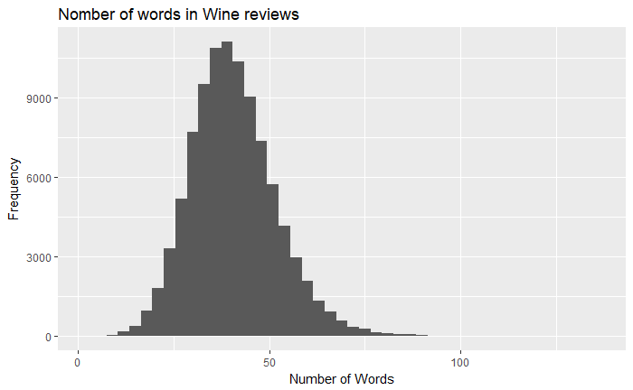

```r
ggplot(data = df.train, aes(x= wordcount))+geom_histogram(binwidth = 3)+labs(x = "Number of Words", y= "Frequency", title = "Nomber of words in Wine reviews")
```

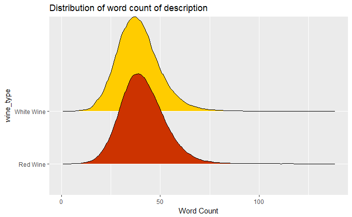

```r
ggplot(data = df.train, aes(x= wordcount, y= wine_type, fill = wine_type))+
  geom_density_ridges()+ labs(x = "Word Count", title = "Distribution of word count of description")+
  scale_fill_cyclical(values = c("#CC3300", "#FFCC00"))
```

[figure not shown]

```r
ggplot(data = df.train, aes(x=variety, y=wordcount))+
  geom_boxplot()+
  coord_flip()+
  labs(title = "Wordcount Distribution by Variety", x= "Variety", y= "Word Count")
```

Let’s take as an example the Red Blend Wines - and perform Text Mining on their reviews

```r
# in this chunk we will use:
#library("tm")
#library("SnowballC")
#library("wordcloud")
#library("RColorBrewer")
#---------- Red Wines Word cloud ----------#
#pinot <- subset(df.test, wine_type == "Red Wine")
pinot <- subset(df.test, variety == "Red Blend")
descriptors <- Corpus(VectorSource(pinot$description))
head(descriptors)
```

```
<<SimpleCorpus>>
Metadata:  corpus specific: 1, document level (indexed): 0
Content:  documents: 6
```

```r
# Convert the text to lower case
descriptors <- tm_map(descriptors, content_transformer(tolower))
# Remove numbers
descriptors <- tm_map(descriptors, removeNumbers)
# Remove english common stopwords
descriptors <- tm_map(descriptors, removeWords, stopwords("english"))
# Remove your own stop word
# specify your stopwords as a character vector
descriptors <- tm_map(descriptors, removeWords, c("wine", "pinot", "noir", "drink", "flavors"))
# Remove punctuations
descriptors <- tm_map(descriptors, removePunctuation)
# Eliminate extra white spaces
descriptors <- tm_map(descriptors, stripWhitespace)
# Text stemming
#descriptors <- tm_map(descriptors, stemDocument)
# Build a term-document matrix
dtm <- TermDocumentMatrix(descriptors)
dtm_mat <- as.matrix(dtm)
v <- sort(rowSums(dtm_mat),decreasing=TRUE)
d <- data.frame(word = names(v),freq=v)
head(d, 20)
```

|  | word | freq |
| --- | --- | --- |
| aromas | aromas | 874 |
| blend | blend | 820 |
| palate | palate | 774 |
| black | black | 757 |
| tannins | tannins | 753 |
| cherry | cherry | 736 |
| cabernet | cabernet | 576 |
| red | red | 556 |
| fruit | fruit | 549 |
| finish | finish | 468 |

[output cut: 10 more lines]

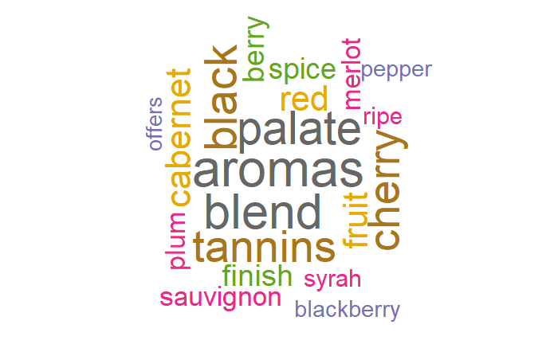

```r
# Generate the Word cloud
set.seed(1234)
wordcloud(words = d$word, freq = d$freq, min.freq = 1,
          max.words=20, random.order=FALSE, rot.per=0.35,
          colors=brewer.pal(8, "Dark2"))
```

Applying NLP Methods for Text Mining and Clustering

```r
# Text Mining and clustering
# in this chunk we will use:
#library(tm)
#library(proxy)
#library(RTextTools)
#library(fpc)
#library(wordcloud)
#library(cluster)
#library(stringi)
```

```r
corpus = Corpus(VectorSource(pinot$description))
# summary(corpus)
ndocs <- length(corpus)
# ignore extremely rare words i.e. terms that appear in less then 1% of the descriptions
minTermFreq <- ndocs * 0.01
# ignore overly common words i.e. terms that appear in more than 50% of the descriptions
maxTermFreq <- ndocs * .5
dtm = DocumentTermMatrix(corpus,
                         control = list(
                                        stopwords = TRUE,
                                        wordLengths=c(4, 15),
                                        removePunctuation = T,
                                        removeNumbers = T,
                                        stemming = T,
                                        bounds = list(global = c(minTermFreq, maxTermFreq))
                                       ))
#dtm <- dtm[, names(head(sort(colSums(as.matrix(dtm))), 400))]
#dtm <- dtm[, names(sort(colSums(as.matrix(dtm))))]
#print(as.matrix(dtm))
write.csv((as.matrix(dtm)), "test.csv")
#head(sort(as.matrix(dtm)[18,], decreasing = TRUE), n=15)
dtm.matrix = as.matrix(dtm)
#wordcloud(colnames(dtm.matrix), dtm.matrix[28, ], max.words = 20)
inspect(dtm)
```

```
<<DocumentTermMatrix (documents: 1733, terms: 400)>>
Non-/sparse entries: 34157/659043
Sparsity           : 95%
Maximal term length: 15
Weighting          : term frequency (tf)
Sample             :
      Terms
Docs   black blend cabernet cherri flavor fruit palat spice tannin wine
  1069     0     1        2      2      2     2     2     1      1    0
  1371     2     0        0      1      0     1     1     1      1    0
  1631     2     1        2      0      1     2     1     1      0    0
  1697     1     0        0      1      0     1     1     1      1    0
  199      0     0        0      1      0     0     1     1      1    1
  217      1     0        0      1      0     0     1     0      1    0
  640      1     1        1      1      1     0     1     2      1    0
  725      0     0        0      1      0     0     1     1      1    1
  764      1     1        0      1      0     2     1     1      2    0
  978      3     0        0      1      0     0     1     0      1    0
```